# Visualization for Data Exploration & Communication

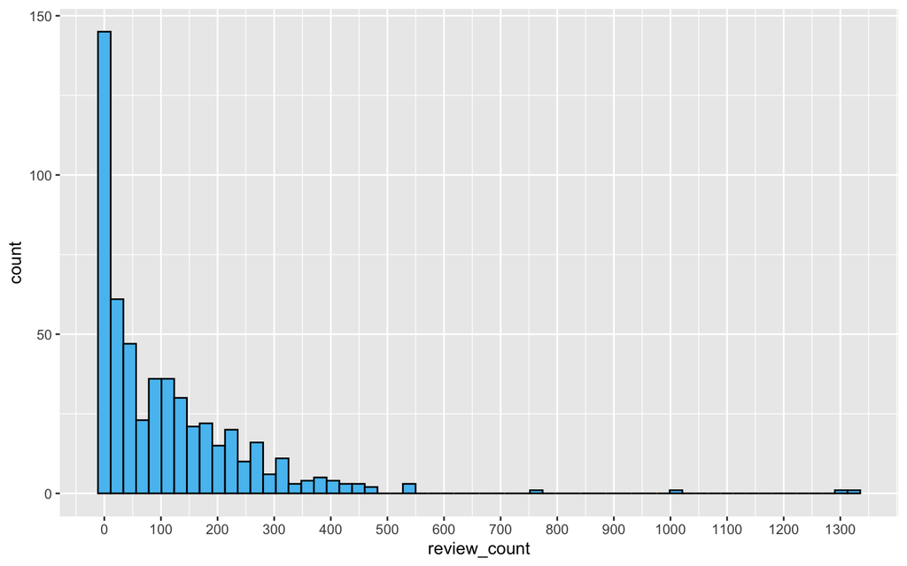

```r
ggplot(census_restaurants) +
  geom_histogram(mapping = ????(x = ????),
                 bins = 60,
                 color="black") +
  scale_x_continuous(breaks=seq(0,1300, by=100)) #👈
```

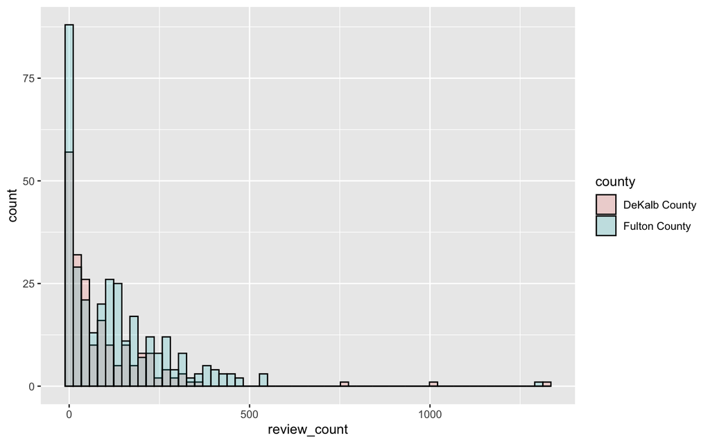

```
## <ScaleContinuousPosition>
##  Range:
##  Limits:    0 --    1
```

```r
ggplot( census_restaurants) +
  geom_histogram(mapping = ????(x = ????, fill=county), #👈
                 bins = 60,
                 color="black",
                 position = "identity", #👈
                 alpha = 0.2) #👈
  scale_x_continuous(breaks=seq(0,1300, by=100))
```

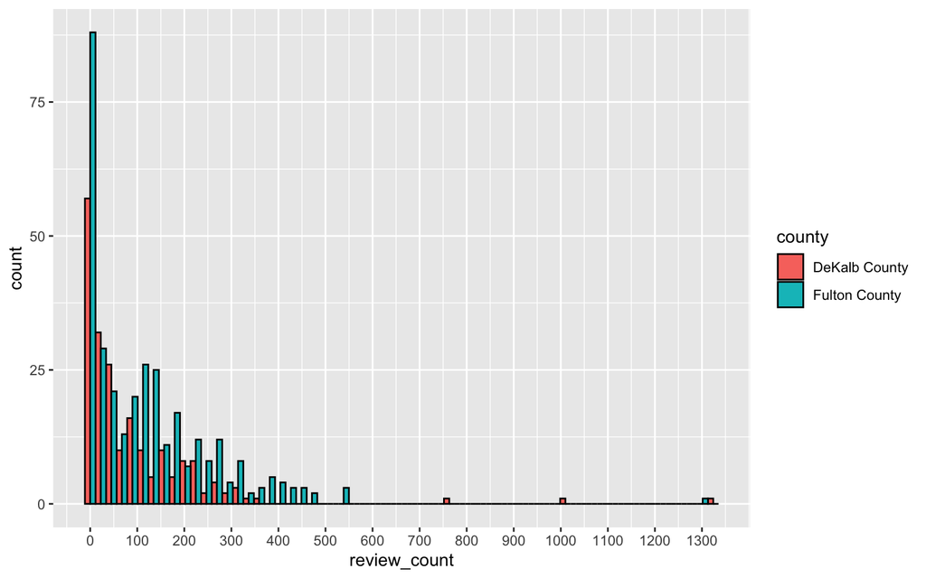

```r
ggplot(census_restaurants) +
  geom_histogram(mapping = ????(x = ????, fill=county),
                 bins = 60,
                 color="black",
                 position = "dodge") + #👈
  scale_x_continuous(breaks=seq(0,1300, by=100))
```

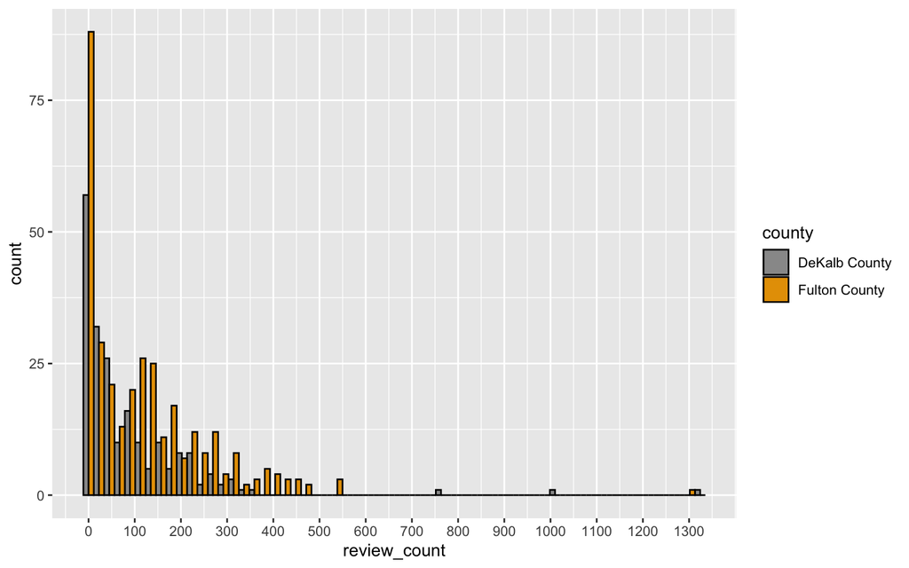

```r
ggplot(census_restaurants) +
  geom_histogram(mapping = ????(x = ????, fill=county),
                 bins = 60,
                 color="black",
                 position = "dodge") +
  scale_x_continuous(breaks=seq(0,1300, by=100)) +
  scale_fill_manual(values=c("#999999", "#E69F00")) #👈
```

## 2D histogram

If you want to examine the distribution of two continuous variables simultaneously, a 2D histogram (or bivariate binning plot) is a good choice. It divides the plot area into bins and counts the number of points in each bin, with colors representing the number of observations.

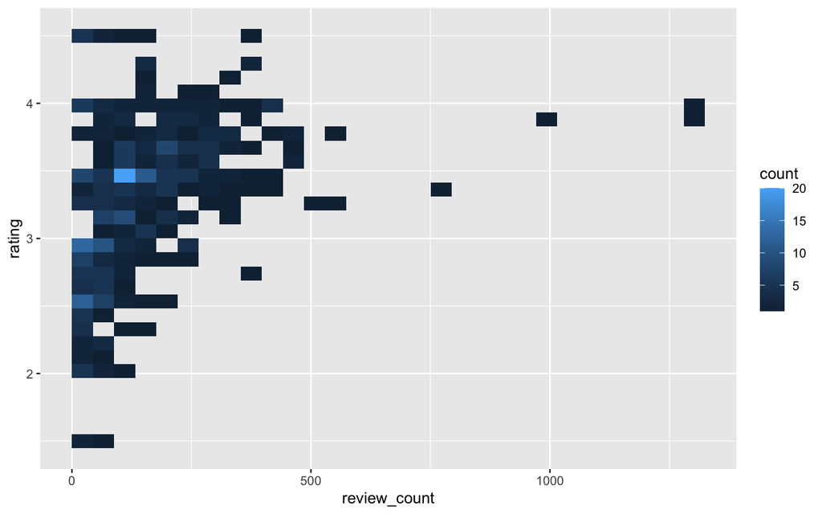

```r
ggplot(census_restaurants) +
  geom_bin2d(mapping = aes(x = review_count, y=rating))
```

## Box plot

Although the histogram allows us to effectively see the distribution, comparing **multiple distributions** are often easier with a box plot. You need to understand what each component of a box plot means to read it properly. `plotly::ggplotly()` provides a good interactive visualization about how to read the plot. Note that upper fence = Q3 + (1.5*IQR), where IQR is interquartile range (Q3-Q1). The lower fence is Q1 - (1.5*IQR).

```r
# Reset the point color changed by theme_modern_rc()
update_geom_defaults("point", list(color = "black"))

bxplot <- ggplot(data = restaurants) +
  geom_boxplot(aes(x=price, y=review_count),
               color="black",fill="white")

plotly::????(bxplot)
```

[interactive chart not shown]

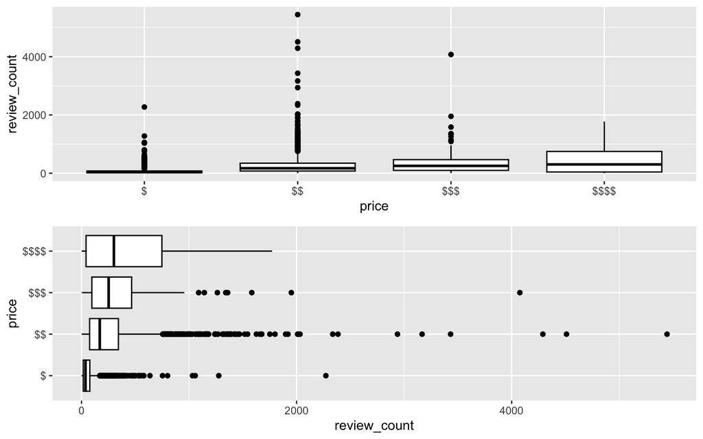

```r
a <- ggplot(data = restaurants) +
  geom_boxplot(aes(x=price, y=review_count),
               fill = "white", color = "black")

b <- ggplot(data = restaurants) +
  geom_boxplot(aes(x=review_count, y=price),
               fill="white", color="black")

gridExtra::grid.arrange(a, b)
```

You can use `scale_fill_manual()` to use your custom color. To do this, however, you need to have specified `fill` inside `aes()`. If it is not specified at all or is specified outside of `aes()`, custom color won’t work.

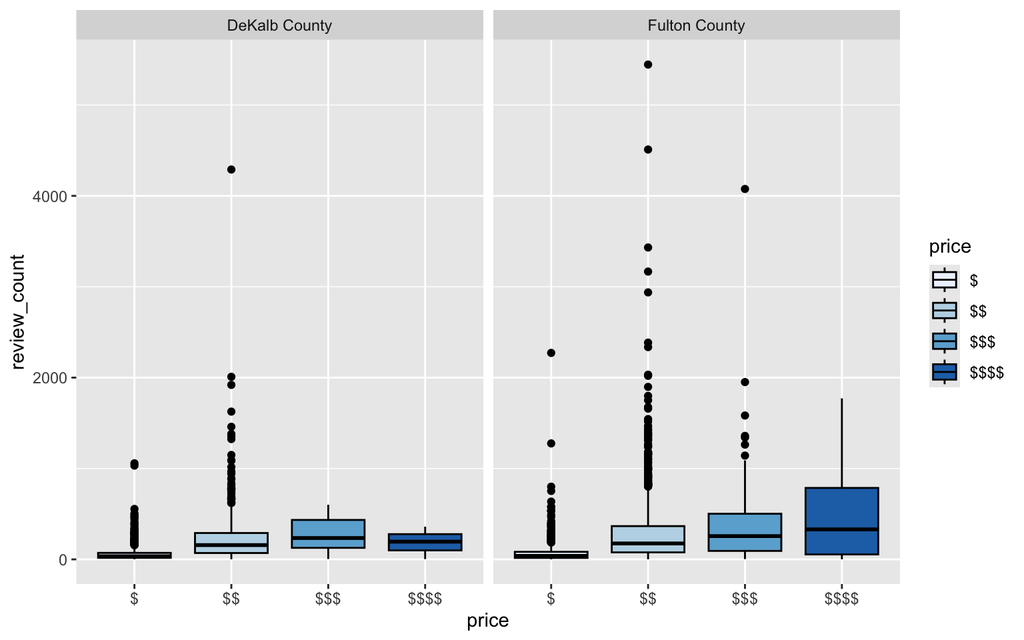

```r
restaurants %>%
  st_join(census %>% st_transform(crs = st_crs(restaurants))) %>%
  separate(col = NAME, into=c("tract","county","state"),sep="; ") %>%
  drop_na(county) %>%
  ggplot() +
  geom_boxplot(aes(x = price, y=review_count, fill = price),
               color = "black") +
  facet_wrap(~county) +
  scale_fill_brewer(palette = "Blues")
```

## Violin plot

Violin plot is yet another plot for visualizing the distribution of variables. While a box plot allows you to see where the upper/lower fences are and where the median and quartiles are, a violin plot allows you to see the concentration of observations at a certain bins (or range if you will) of values.

```r
vplot <- ggplot(data = restaurants %>%
                  st_join(census %>% st_transform(crs = st_crs(restaurants))) %>%
                  separate(col = NAME, into=c("tract","county","state"),sep="; ") %>%
                  drop_na(county)) +
  geom_violin(aes(x = price, y=review_count, fill = price),
               color = "black") +
  facet_wrap(~county) +
  scale_fill_brewer(palette = "Blues")

plotly::ggplotly(vplot)
```

[interactive chart not shown]

# Network visualization (Optional)

Another interesting type of visualization we can do in R is a network graph. Network graphs are particularly useful for exploring **connections and co-occurrences** in data, which can be difficult to see in traditional plots or maps.

Suppose we are interested in examining how restaurant categories are related. Often, POIs are not classified into a single type but into multiple categories, such as:

```r
print(restaurants$categories[restaurants$name == "Tin Drum"][1])
```

```
## [1] "Asian Fusion, Thai, Chinese"
```

Using this information, we create a network graph that represents associations between categories across the entire dataset. This visualization can reveal related groups of categories, popular combinations, and overall patterns in restaurant offerings.

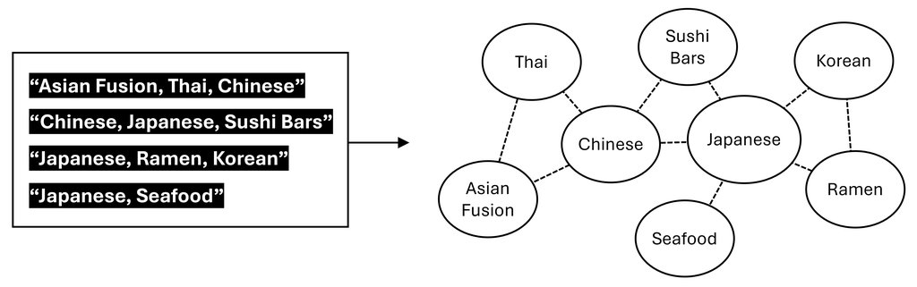

We can create interactive network visualizations using packages like `networkD3`. This package is built on top of `D3.js`, a powerful JavaScript library that provides the underlying rendering engine and interactivity in web browsers.

To do this, we first transform our data into nodes and edges:

- **Nodes** represent unique categories.
- **Edges** represent co-occurrences of categories in the same observation.

## Edges & nodes

If the following code chunk looks complicated, don’t worry–you don’t need to understand every detail to follow along.

```r
library(utils)

# Split comma-separated strings into a list of character vectors
categories_list <- str_split(restaurants$categories, ", ")

# Create an edge list
edges <- categories_list %>%
  map_dfr(function(x) {
    if(length(x) > 1) as.data.frame(t(combn(x, 2))) else NULL}
  )
colnames(edges) <- c("source", "target")

# Clean edges (undirected, unique)
edges %<>%
  rowwise() %>%
  mutate(source = min(c(source, target)),
         target = max(c(source, target))) %>%
  ungroup() %>%
  distinct() %>%
  filter(source != target)

# Get nodes and their frequencies
nodes <- unlist(categories_list)
node_freq <- as.data.frame(table(nodes))
colnames(node_freq) <- c("name", "freq")

# Numeric node ID for networkD3
nodes <- node_freq %>% mutate(id = 0:(n() - 1))

# Replace names with node IDs
edges %<>%
  mutate(source = match(source, nodes$name) - 1,
         target = match(target, nodes$name) - 1)
```

## Force-directed graph

Once the nodes and edges are defined, we can render an interactive force-directed graph, where node size can reflect frequency and edges show relationships between categories.

The following chunk uses JavaScript, and if you don’t understand the JavaScript code, that’s totally fine.

```r
fn <- networkD3::forceNetwork(
  Links = edges, Nodes = nodes,
  Source = "source", Target = "target",
  NodeID = "name",
  Group = "name",
  Nodesize = "freq",
  fontFamily = "Verdana",
  opacity = 0.9,
  zoom = TRUE,
  fontSize = 20,
  linkDistance = 200,
  linkWidth = 0.3,
  linkColour = "#888",
  charge = -10
)

# Make it look nicer: set background to black and labels to white
fn %>%
  htmlwidgets::onRender(
    JS("function(el, x) {
      var graph = d3.select(el);
      var node = graph.selectAll('.node');
      graph.select('svg').style('background-color', 'black');
      node.select('text').style('fill', 'white');

      var neighbors = {};
      HTMLWidgets.dataframeToD3(x.links).forEach(function(link) {
        neighbors[link.source + ',' + link.target] = true;
        neighbors[link.target + ',' + link.source] = true;
      });

      node.on('mouseover.neighborLabels', function(d) {
        node.filter(function(other) { return other.index !== d.index; })
          .select('text').interrupt()
          .style('opacity', function(other) {
            return neighbors[d.index + ',' + other.index] ? 1 : x.options.opacityNoHover;
          });
      }).on('mouseout.neighborLabels', function(d) {
        node.filter(function(other) { return other.index !== d.index; })
          .select('text').interrupt()
          .style('opacity', x.options.opacityNoHover);
      });
    }")
)
```

[interactive chart not shown]

# So, do restaurants in wealthy neighborhoods get higher ratings?

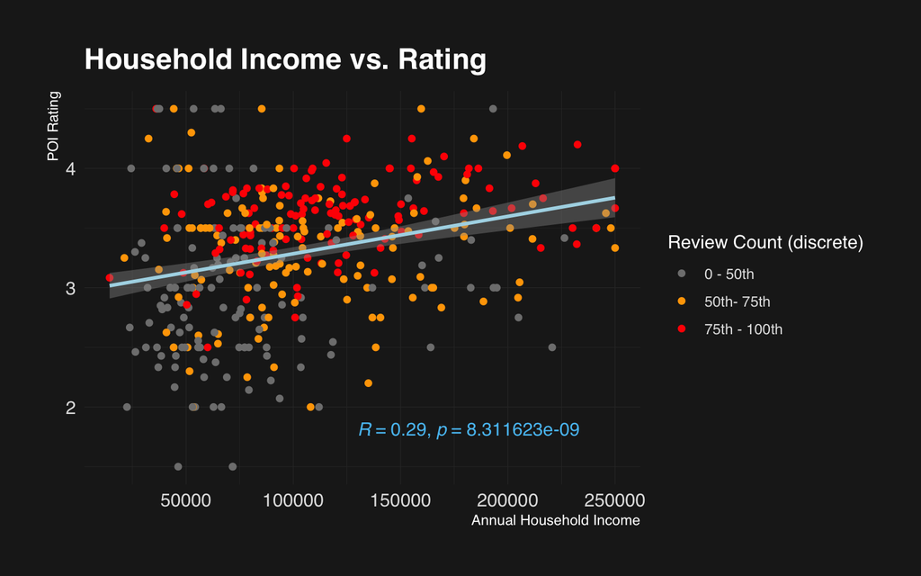

```r
census_restaurants %>%
  mutate(
    review_count_cut = cut(review_count,
                           breaks = quantile(review_count,
                                             prob = c(0,0.5,0.75,1)),
                           include.lowest=TRUE)
  ) %>%
  ggplot(data = ., aes(x = ????, y = ????)) +
  geom_point(mapping = aes(color = review_count_cut)) +
  geom_smooth(method = ????, color = "lightblue") +
  scale_color_manual(values = c("gray50", "orange", "red"),
                     labels = c("0 - 50th", "50th- 75th", "75th - 100th")) +
  labs(x = "Annual Household Income",
       y = "POI Rating",
       color = "Review Count (discrete)",
       title = "Household Income vs. Rating") +
  hrbrthemes::theme_modern_rc(
    base_family = "sans", subtitle_family = "sans", caption_family = "sans"
  ) +

  # ------------------------------------------------------------------
  # This line of code adds the correlation analysis result to the plot
  ggpubr::stat_cor(method = "pearson", label.x = 130000, label.y = 1.8)
```

> What do you think? Is household income associated with POI rating?

As we’ve seen, data visualization is an indispensable tool for urban analysts. If we have some time left in class, consider socioeconomic or demographic variables from the American Community Survey that might be associated with POI review count, rating, or price. Then, gather the data, create plots, and draw insights from your findings.